# combined model

Talladega Bites

2025-04-02

#Talladega Bites

```r
#remotes::install_github("eco4cast/neon4cast")
library(tidyverse)
library(neon4cast)
library(lubridate)
library(rMR)
library(arrow)
library(rjags)
```

```r
require(ggplot2)
forecast_date <- lubridate::as_date("2016-01-01")

  ## load site data
site_data <- readr::read_csv("https://raw.githubusercontent.com/eco4cast/neon4cast-targets/main/NEON_Field_Site_Metadata_20220412.csv") |>
  dplyr::filter(ticks == 1)
tall_data <- site_data[8, ]

  # tick data
ticks_data <- readr::read_csv("https://data.ecoforecast.org/neon4cast-targets/ticks/ticks-targets.csv.gz", guess_max = 1e6)
TALL_ticks <- ticks_data[ticks_data$site_id == 'TALL',]

# Add a column that converts the 'date' to a 'month'.
TALL_ticks$month <- month(TALL_ticks$datetime, label=TRUE)

# add another column for year
TALL_ticks$year <- year(TALL_ticks$datetime)
```

```r
# wrangled in python, will update when i turn the .ipynb into R script -- PG
weather_data <- read_csv("monthly_avg_temp.csv")
library(dplyr)
library(tidyr)

# Convert 'month' to a character and create 'month-year' in the tick data
TALL_ticks <- TALL_ticks %>%
  mutate(month_year = paste0(year, "-", formatC(as.numeric(month), width = 2, flag = "0")))

# Merge with weather data and drop rows with missing monthly_avg
combined_data <- TALL_ticks %>%
  left_join(weather_data, by = c("month_year" = "month-year")) %>%
  drop_na(monthly_avg)

# view result
head(combined_data)
```

```
## # A tibble: 6 × 9
##   datetime   site_id variable        observation iso_week month  year month_year
##   <date>     <chr>   <chr>                 <dbl> <chr>    <ord> <dbl> <chr>
## 1 2015-06-01 TALL    amblyomma_amer…       101.  2015-W23 Jun    2015 2015-06
## 2 2015-06-22 TALL    amblyomma_amer…        60.2 2015-W26 Jun    2015 2015-06
## 3 2015-07-13 TALL    amblyomma_amer…        84.3 2015-W29 Jul    2015 2015-07
## 4 2015-08-03 TALL    amblyomma_amer…        19.6 2015-W32 Aug    2015 2015-08
## 5 2015-08-24 TALL    amblyomma_amer…        70.7 2015-W35 Aug    2015 2015-08
## 6 2015-09-14 TALL    amblyomma_amer…        47.9 2015-W38 Sep    2015 2015-09
## # ℹ 1 more variable: monthly_avg <dbl>
```

# Quick Model Summary

For our combined internal and external factors model, we estimate mean tick count at time *i* (X[i]) using a carrying capacity model (internal factor, density dependence) where **K** (carrying capacity) and **r** (growth rate) are dependent on **temperature** (external factor) and the state equation includes a term for **process error** (E).

To fit the model to historical data, we need months where we have both a tick count and a mean temperature, which is why you see me dropping rows missing one or the other in the code blocks above. Below, I define the model in JAGS-speak. Note that process error (E), r, and K are defined for each model loop. B0, B1 are the temperature effects on the rate variable, and B2, B3 are the temperature effects on the K, which shouldn’t be changing, so they are not defined in each loop. We also have priors on the initial conditions at X[1], since at the first time point, we aren’t sure what the ticks or temp at t-1 were.

r and K are linear relationships for now, but that may have to be adjusted. I have also wrapped K in an exponential function to avoid any negative values. I initially just put a max(0.001) term on it, but that introduced issues with the traceplots (the chains were getting hung at 0.001); using exp() gives the distribution smoother approach to 0 and allows the MCMC to keep running more smoothly.

```r
combined_logistic <- "
model{

  ## priors
  x_ic ~ dnorm(0,0.1)      ## uninformative prior for initial condition of state equation
  tau_ic ~ dgamma(0.1,0.1)  ## uninformatiev prior for precision of ic of state

  X[1] ~ dnorm(x_ic,tau_ic) ## prior on initial condition, x_ic and tau_ic need to be defined in data
  tau ~ dgamma(0.1,0.1)     ## precision for process error

  B0 ~ dnorm(0,0.1)         ## uninformative prior on rate y-intercept
  B1 ~ dnorm(0,0.1)         ## uninformative prior on rate slope

  B2 ~ dnorm(0,0.1)         ## uninformative prior on carrying capacity y-intercept
  B3 ~ dnorm(0,0.1)         ## uninformative prior on carrying capacity slope


  ## process model
    for(i in 2:Ni){
      E[i] ~ dnorm(0,tau)                    ## process error (normally distributed with tau precision)
      r[i] <- B0 + B1*temp[i]                   ## rate given temp
      K[i] <- exp(B2 + B3 * temp[i])  # ensures positivity without a hard bound (thank u ChatGPT)
      X[i] <- X[i-1] + r[i]*X[i-1]*(1 - X[i-1]/K[i]) + E[i] ## state equation (logistic growth with process noise)
    }

  ## data model
    for(i in 1:Ni){
      y[i] ~ dpois(max(0.001, X[i]))  # Ensures positive values only
    }
}
"
```

Here I am defining data for the model and initializing it in JAGS. Note that I round the tick counts (y) to integers, since we are using a poisson distribution for y[i].

```r
data <- list(y=combined_data$observation, Ni=length(combined_data$observation),      ## tick data
             temp=combined_data$monthly_avg               ## weather inputs
             )
data$y <- round(data$y)  # Round values to integers

j.model   <- jags.model (file = textConnection(combined_logistic),
                             data = data,
                             n.chains = 5)
```

And here we have the actual model running step. You can see that I have a lot of iterations and a burn-in period to help with convergence (which we’re still not achieving with most, if not all, of the variables).

```r
out_1   <- coda.samples (model = j.model,
                          variable.names = c("K","r","y", "B0", "B1", "B2", "B3", "E"),
                          n.iter = 50000,
                          burnin=5000)
```

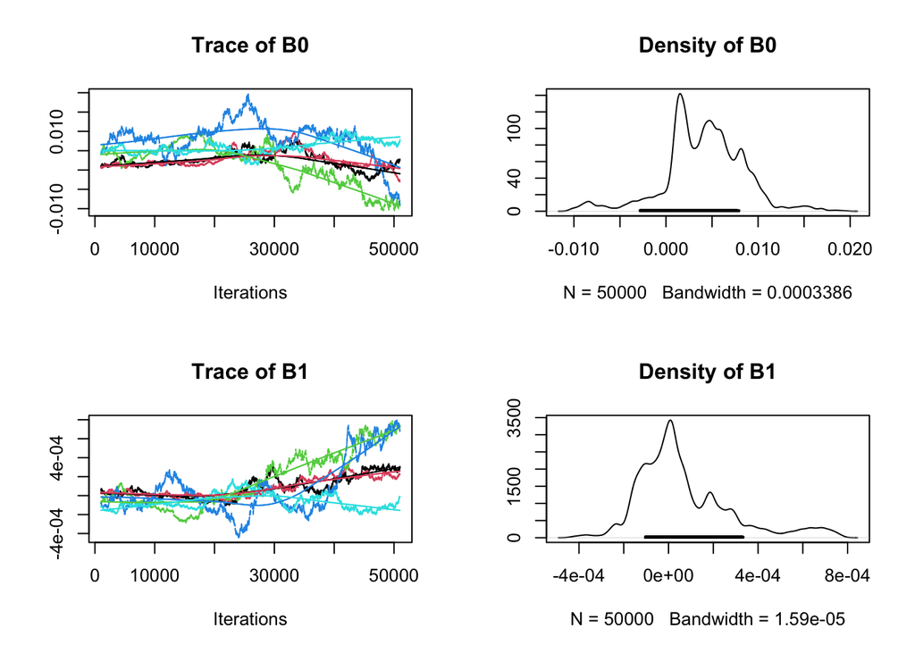

```r
plot(out_1[, c("B0", "B1")])
```

B0 and B1 traceplots look awful – the MCMC chains are having issues converging.

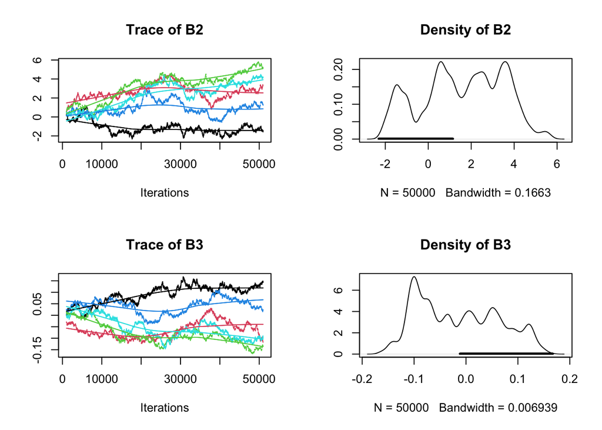

```r
plot(out_1[, c("B2", "B3")])
```

Same goes for B2 and B3. I will note that the magnitude of B2 (intercept temp term for K) is on a different order of magnitude than any of the other temp terms, which is interesting but also untrustworthy if nothing is converging.

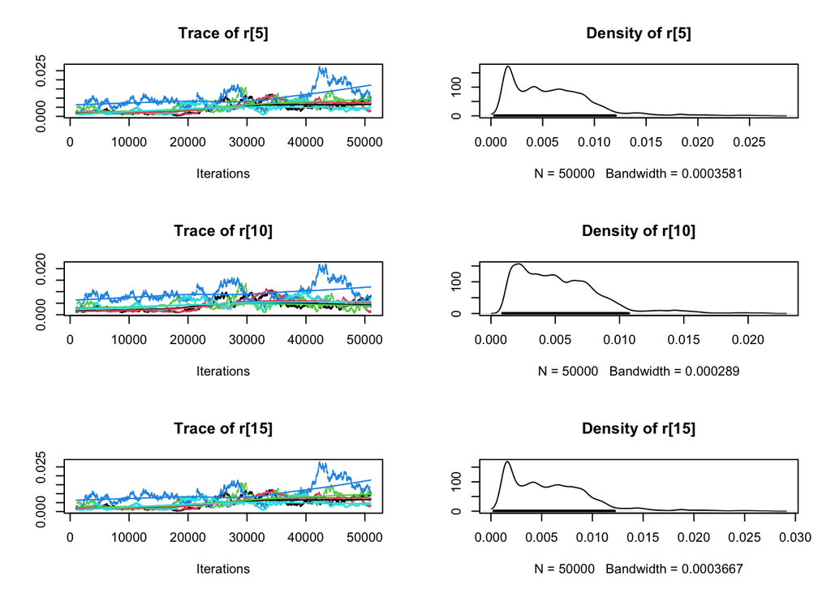

```r
plot(out_1[, c("r[5]", "r[10]", "r[15]")]) # just looking at a few since plotting them all breaks this line
```

We (once again) see issues with convergence in the rate term.

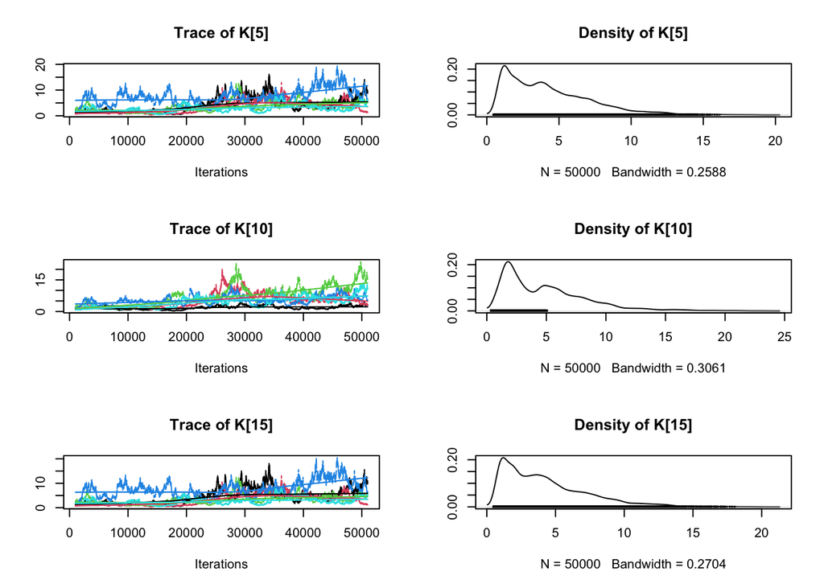

```r
plot(out_1[, c("K[5]", "K[10]", "K[15]")])
```

And some interesting dynamics nonconvergence dynamics in the K term. I am happy to see that it is changing between model runs, which I would expect to be true in a biological sense given how much the y varies between months.

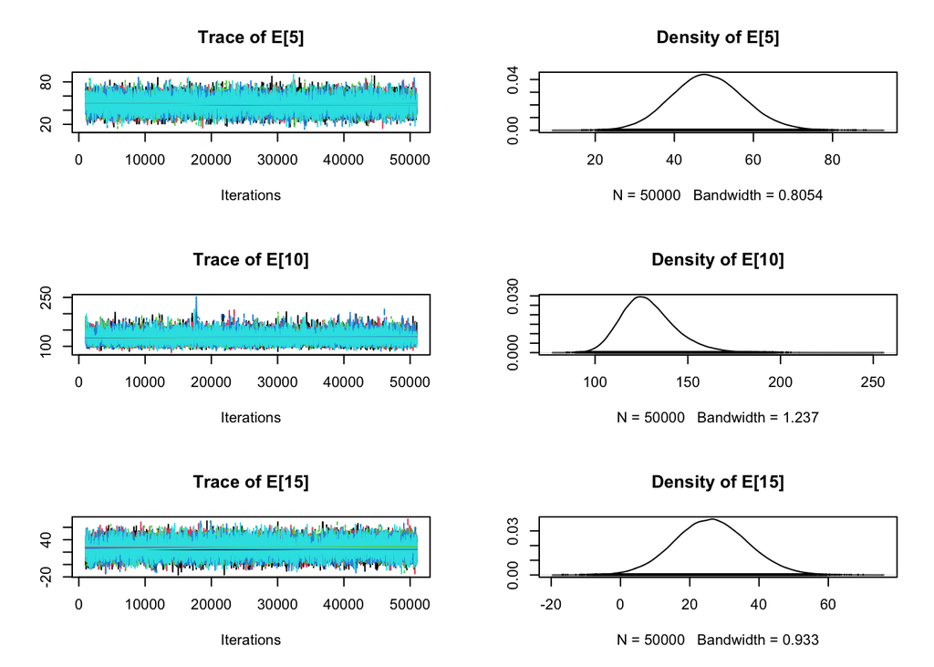

```r
plot(out_1[, c("E[5]", "E[10]", "E[15]")])
```

Wow! I am so glad to see some fuzzy caterpillars! What’s not great is how large the process error is compared to our other variables. :’) That’s saying the unpredictability in the biological process is very high. There is a reason I suspect this is happening – I’ll talk more about it in the write up at the end.

Okay now we’re looking at official convergence metrics for the variables:

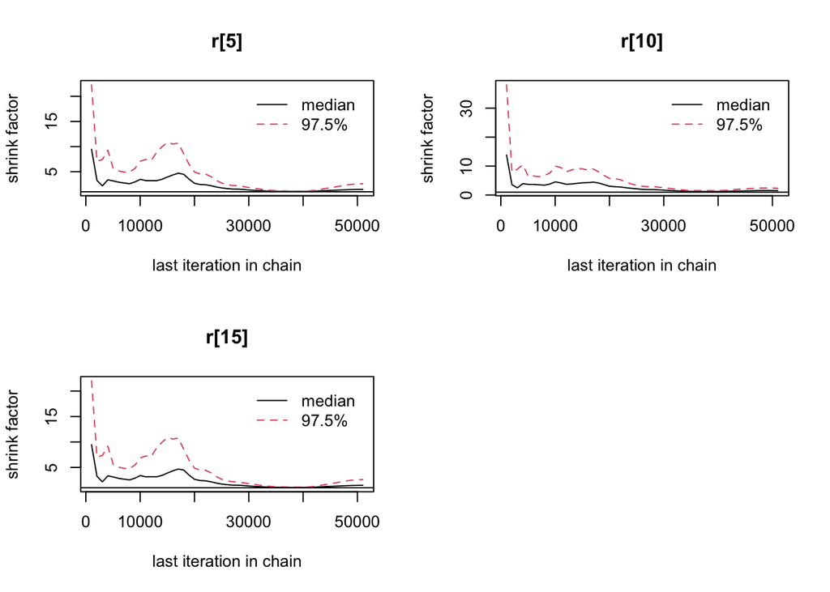

```r
gelman.plot(out_1[, c("r[5]", "r[10]", "r[15]")])
```

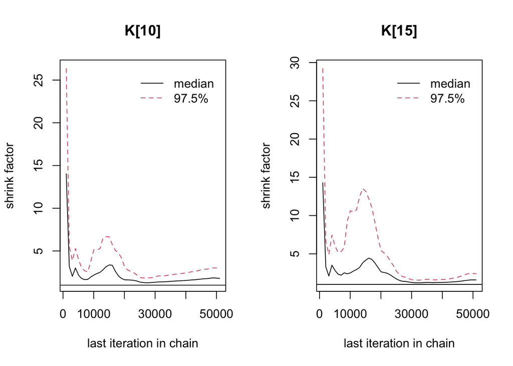

```r
gelman.plot(out_1[, c("K[10]", "K[15]")])
```

```r
#gelman.plot(out_1[, c("y[5]", "y[10]", "y[15]")])

# the file won't knit if this line runs -- but here is the error i get:

#******* Error: *******
#Cannot compute Gelman & Rubin's diagnostic for any chain
#segments for variables y[5] y[10] y[15]
#This indicates convergence failure
```

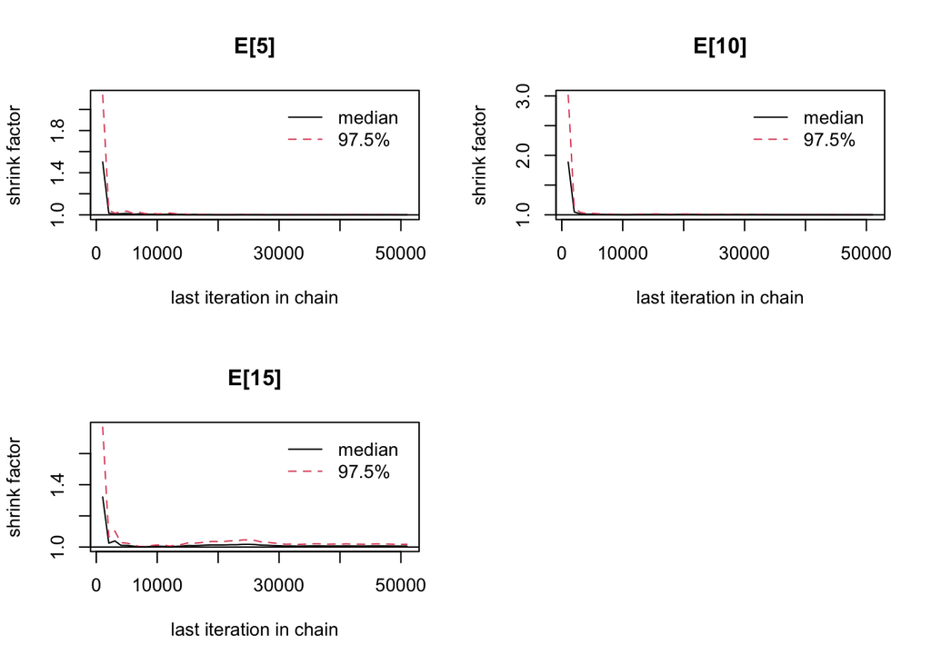

```r
gelman.plot(out_1[, c("E[5]", "E[10]", "E[15]")])
```

None of these look like they’re converging to me except for the process error terms. The y terms are so bad that the gelman function can’t even plot them.

```r
gelman.diag(out_1[, c("B0", "B1", "B2", "B3")])
```

```
## Potential scale reduction factors:
##
##    Point est. Upper C.I.
## B0       1.63       2.62
## B1       1.53       3.00
## B2       4.43       7.53
## B3       4.43       7.50
##
## Multivariate psrf
##
## 4.09
```

```r
gelman.diag(out_1[, c("K[5]", "K[10]", "K[15]",
                      "r[5]", "r[10]"
                      )])
```

```
## Potential scale reduction factors:
##
##       Point est. Upper C.I.
## K[5]        1.51       2.21
## K[10]       1.80       2.95
## K[15]       1.59       2.40
## r[5]        1.49       2.60
## r[10]       1.51       2.33
##
## Multivariate psrf
##
## 2.52
```

```r
#gelman.diag(out_1[, c("y[5]", "y[10]", "y[15]")])

# again, file won't knit with this line. Error below:
# Error in chol.default(W) : the leading minor of order 1 is not positive
```

```r
gelman.diag(out_1[, c("E[5]", "E[10]", "E[15]")])
```

```
## Potential scale reduction factors:
##
##       Point est. Upper C.I.
## E[5]        1.00       1.00
## E[10]       1.00       1.00
## E[15]       1.01       1.02
##
## Multivariate psrf
##
## 1.01
```

Above, confirming what the traceplots and BGR plots (and my heart) told us, none of the BGR metrics are below 1.1, which tells us the variables have not converged. :( Except for our superstar E (process error) term! It’s nice to have a positive control for what a converged variable might look like, if nothing else.

Let’s look at some summary statistics:

```r
summary(out_1[, c("y[5]", "y[10]", "y[15]",
              "K[5]", "K[10]", "K[15]",
              "r[5]", "r[10]", "r[15]",
              "B0", "B1", "B2", "B3",
              "E[5]", "E[10]", "E[15]")])
```

```
##
## Iterations = 1001:51000
## Thinning interval = 1
## Number of chains = 5
## Sample size per chain = 50000
##
## 1. Empirical mean and standard deviation for each variable,
##    plus standard error of the mean:
##
##             Mean        SD  Naive SE Time-series SE
## y[5]   7.100e+01  0.000000 0.000e+00      0.000e+00
## y[10]  1.260e+02  0.000000 0.000e+00      0.000e+00
## y[15]  7.900e+01  0.000000 0.000e+00      0.000e+00
## K[5]   4.276e+00  2.932750 5.865e-03      3.063e-01
## K[10]  4.842e+00  3.468897 6.938e-03      4.818e-01
## K[15]  4.306e+00  3.093306 6.187e-03      3.134e-01
## r[5]   5.864e-03  0.004058 8.116e-06      7.342e-04
## r[10]  5.345e-03  0.003294 6.587e-06      5.043e-04
## r[15]  5.913e-03  0.004156 8.311e-06      7.631e-04
## B0     4.106e-03  0.004302 8.605e-06      8.361e-04
## B1     6.813e-05  0.000212 4.240e-07      5.795e-05
## B2     1.575e+00  1.884677 3.769e-03      2.815e-01
## B3    -1.449e-02  0.078631 1.573e-04      1.009e-02
## E[5]   4.848e+01  9.126639 1.825e-02      9.493e-02
## E[10]  1.289e+02 14.847575 2.970e-02      1.568e-01
## E[15]  2.622e+01 10.572447 2.114e-02      9.234e-02
##
## 2. Quantiles for each variable:
##
##             2.5%        25%        50%       75%     97.5%
## y[5]   7.100e+01  71.000000  7.100e+01 7.100e+01 7.100e+01
## y[10]  1.260e+02 126.000000  1.260e+02 1.260e+02 1.260e+02
## y[15]  7.900e+01  79.000000  7.900e+01 7.900e+01 7.900e+01
## K[5]   7.809e-01   1.894044  3.687e+00 5.978e+00 1.158e+01
## K[10]  8.004e-01   2.026434  4.164e+00 6.708e+00 1.360e+01
## K[15]  7.498e-01   1.843375  3.618e+00 5.948e+00 1.218e+01
## r[5]   1.115e-03   0.002515  5.268e-03 8.070e-03 1.644e-02
## r[10]  1.299e-03   0.002751  4.793e-03 7.139e-03 1.430e-02
## r[15]  1.045e-03   0.002492  5.266e-03 8.190e-03 1.661e-02
## B0    -7.162e-03   0.001615  4.227e-03 6.756e-03 1.245e-02
## B1    -2.331e-04  -0.000071  1.682e-05 1.704e-04 6.671e-04
## B2    -1.798e+00   0.288959  1.730e+00 3.206e+00 4.663e+00
## B3    -1.357e-01  -0.086072 -2.385e-02 5.063e-02 1.299e-01
## E[5]   3.106e+01  42.254915  4.828e+01 5.452e+01 6.691e+01
## E[10]  1.042e+02 118.624055  1.273e+02 1.374e+02 1.625e+02
## E[15]  5.697e+00  19.051344  2.611e+01 3.324e+01 4.739e+01
```

# The Write Up

Our variables are not converging across the board (except for process error), despite a high number of chains and iterations. I think this is due, in part, to a few issues. The first being that we have super super uninformative priors for most of our variables. I think to improve model accuracy, I would try more informative priors – maybe based on the averages that I see from these variables? Or we could do a lit review and try to estimate it from there.

Another issue is that we have non-uniform time steps between data points. For example, the first five dates of the ticks data look like this:

```r
head(ticks_data$datetime)
```

```
## [1] "2015-04-20" "2015-05-11" "2015-06-01" "2015-06-08" "2015-06-22"
## [6] "2015-07-13"
```

We go from 4/20 - 5/11 (21 days) in rows 1 and 2 to 6/01 - 6/08 (7 days) in rows 3 and 4. The model is assuming an equal time between all data points; to fix this, we could add a loop in the model that runs, recursively, the number of days between each time point (i.e. would run 21 times between row 1 and 2 vs. 7 times between rows 3 and 4). I think this problem is partially the source of a high process error in the model; the system seems unpredictable to the model because it’s not getting the full scope of the data and it’s stitching together an incomplete picture.

I would like to try implementing these fixes before the next project milestone, but unfortunately wasn’t able to complete them before the deadline. @ProfJody – what are your thoughts? Do you agree with the convergence maybe being caused by these issues and the proposed fixes?